# assignment 6

Viviana

2022-04-06

# Assignment 6_ update

Previously I misunderstood question number b, therefore I rewrote and I am correcting the file!

1. Choose a transcription factor, e.g. CREB1, REST, GATA5, EGR1, GCR (or any of your choice that has a motif and available ChIPseq data)
2. Download the (e.g. Mouse) peaks for that factor (whatever cell type)
3. Identify the instances of the factor’s motif

Answer the following questions: a. Of all the peaks, what proportion contains a motif for the factor? (Expected form of an answer: “of the XX peaks, XX (XX%) contain a motif”) b. Of all instances of that motif in the genome, what proportion is bound by the factor (i.e. has a peak)? (Expected form of an answer: “of the XX motif instances, XX (XX%) overlap a peak”)

Don’t forget to render your markdown and push it as assignment.html !

```r
suppressPackageStartupMessages({
  library(GenomicRanges)
  library(memes)
  library(Biostrings)
  library(AnnotationHub)
  library(MotifDb)
  library(universalmotif)
  library(PWMEnrich)
  library(ggplot2)
})
```

```
## See system.file("LICENSE", package="MotifDb") for use restrictions.
```

```r
download.file("https://www.encodeproject.org/files/ENCFF978KGB/@@download/ENCFF978KGB.bed.gz", "creb_ENCFF978KGB.bed.gz")
peaks <- rtracklayer::import("creb_ENCFF978KGB.bed.gz", format="NarrowPeak")
seqlevelsStyle(peaks) <- "Ensembl"
peaks_chr1 <- peaks[seqnames(peaks)=="1"]
```

```r
peak_centers <- resize(peaks_chr1, fix="center", width=100)
# we get the genome sequence:
ah <- AnnotationHub(localHub=FALSE)
```

```
## snapshotDate(): 2021-10-20
```

```r
genome <- ah[["AH49723"]]
```

```
## loading from cache
```

```
## require("rtracklayer")
```

```r
# we get the sequences corresponding to the peak centers:
peak_seqs <- memes::get_sequence(peak_centers, genome)
length(peak_centers)
```

```
## [1] 2015
```

```r
length(peak_seqs)
```

```
## [1] 2015
```

```r
peak_seqs
```

```
## DNAStringSet object of length 2015:
##        width seq                                            names
##    [1]   100 GAGATCAAGGTACTCACTGCGT...TGACGTGTTCCATGGCAGGGA 1:228109244-22810...
##    [2]   100 CTCGCAGGCGCAGGCGCAGGGC...GTTCTGCCAGCGCCACGTCAT 1:26432223-26432322
##    [3]   100 AGCCTGAACTTCCAAGAGCAAG...GTCAGGTCCCGTCGTCGCTGC 1:53238468-53238567
##    [4]   100 AAGTGACGCAATCTGTCGCGTC...CACCGGGGTCGAGCCGCGGCG 1:19210321-19210420
##    [5]   100 GGCCACTGAGAGCACCCGGAGT...GGCGGCCGGGGGCAGGGCCAG 1:40161251-40161350
##    ...   ... ...
## [2011]   100 GGCTGCTGGTGCCCGAGCTCTA...GCACAAGTTCGTGGTGCACTC 1:2229455-2229554
## [2012]   100 AGTGCGCGCTGGAGCGGAGGCG...CACGGTGCTTCCCCTGAGGCT 1:226224097-22622...
## [2013]   100 CAGCAAGAAGGGACTGTTTCTA...GGGGGGACACTAGGTCCTCCG 1:26036285-26036384
## [2014]   100 GGCCGCCAGCCTCCAGCCGGCC...CCGGAGCCAGGGGAGACCCGA 1:246566465-24656...
## [2015]   100 GATCGTCGGAGCTTGGGAGCAG...GCGTGGAGGCTGGATGGGGTT 1:24319526-24319625
```

```r
#gadem <- rGADEM::GADEM(peak_seqs, genome=genome)

# we search for "Gata1" in the motif database
motifs <- query(MotifDb, "CREB1")
head(motifs)
```

```
## MotifDb object of length 6
## | Created from downloaded public sources: 2013-Aug-30
## | 6 position frequency matrices from 1 source:
## |         cisbp_1.02:    6
## | 2 organism/s
## |           Hsapiens:    5
## |          Mmusculus:    1
## Mmusculus-cisbp_1.02-M0297_1.02
## Hsapiens-cisbp_1.02-M3083_1.02
## Hsapiens-cisbp_1.02-M3084_1.02
## Hsapiens-cisbp_1.02-M3089_1.02
## Hsapiens-cisbp_1.02-M3090_1.02
## Hsapiens-cisbp_1.02-M4012_1.02
```

```r
# there are several matching motifs:
names(motifs)
```

```
##  [1] "Mmusculus-cisbp_1.02-M0297_1.02"
##  [2] "Hsapiens-cisbp_1.02-M3083_1.02"
##  [3] "Hsapiens-cisbp_1.02-M3084_1.02"
##  [4] "Hsapiens-cisbp_1.02-M3089_1.02"
##  [5] "Hsapiens-cisbp_1.02-M3090_1.02"
##  [6] "Hsapiens-cisbp_1.02-M4012_1.02"
##  [7] "Hsapiens-cisbp_1.02-M4013_1.02"
##  [8] "Hsapiens-cisbp_1.02-M6180_1.02"
##  [9] "Hsapiens-HOCOMOCOv10-CREB1_HUMAN.H10MO.A"
## [10] "Mmusculus-HOCOMOCOv10-CREB1_MOUSE.H10MO.B"
## [11] "Hsapiens-HOCOMOCOv11-core-A-CREB1_HUMAN.H11MO.0.A"
## [12] "Hsapiens-hPDI-CREB1"
## [13] "Rnorvegicus-JASPAR_CORE-CREB1-MA0018.2"
## [14] "Vertebrata-JASPAR_2014-CREB1-MA0018.2"
## [15] "Hsapiens-jaspar2016-CREB1-MA0018.1"
## [16] "Mmusculus-jaspar2016-CREB1-MA0018.2"
## [17] "Hsapiens-jaspar2018-CREB1-MA0018.1"
## [18] "Mmusculus;Rnorvegicus;Hsapiens-jaspar2018-CREB1-MA0018.2"
## [19] "Hsapiens-jaspar2018-CREB1-MA0018.3"
## [20] "Hsapiens-SwissRegulon-CREB1.SwissRegulon"
```

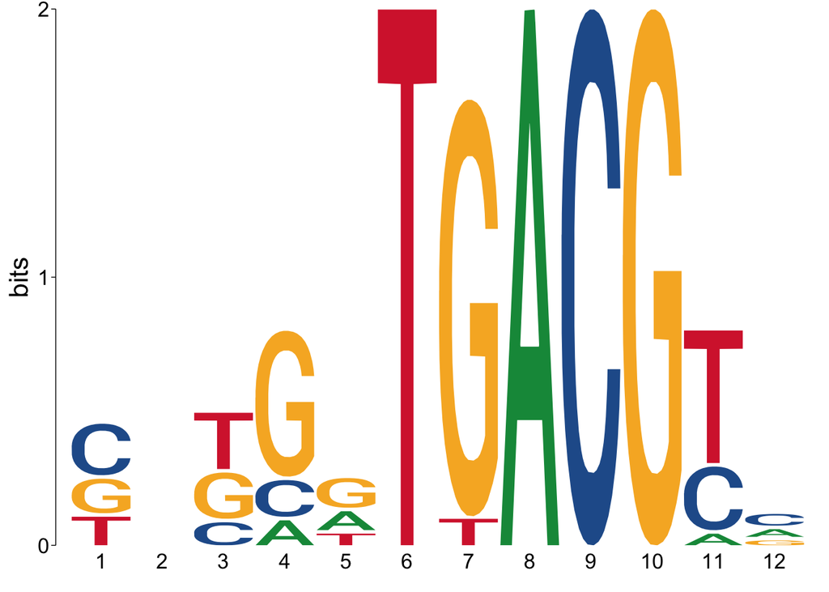

```r
# we select one:
motif <- motifs[["Hsapiens-jaspar2016-CREB1-MA0018.1"]]
# we visualize it:
view_motifs(motif)
```

```r
#' findMotifInstances
#'
#' A wrapper around TFBSTools for scanning motif occurence, handling the
#' coordinate conversion as `memes` does.
#'
#' @param seqs A set of sequences, e.g. `DNAStringSet`, optionally with
#'   coordinate as names to enable conversion.
#' @param motif A motif, in any format recognized by `universalmotif`
#' @param keepMatchedSeq Logical; whether to keep the matched sequence.
#' @param ... Passed to `TFBSTools::searchSeq`; can for instance be used to set
#'   the number of threads to use, e.g. with `mc.cores=2`
#'
#' @return A `GRanges` object
findMotifInstances <- function(seqs, motif, keepMatchedSeq=FALSE, ...){
  motif <- universalmotif::convert_motifs(motif, "TFBSTools-PWMatrix")
  x <- suppressWarnings(TFBSTools::searchSeq(motif, subject=seqs))
  peaks <- strsplit(gsub("-",":",names(seqs)), ":")
  if(all(lengths(peaks)==3)){ # convert relative coordinates to absolute
    chrs <- sapply(peaks,FUN=function(x) x[1])
    offsets <- sapply(peaks,FUN=function(x) as.integer(x[2]))-1L
    i <- rep(seq_along(x),lengths(x))
    return(GRanges(chrs[i],
                   IRanges(offsets[i]+as.integer(unlist(lapply(x, start))),
                           offsets[i]+as.integer(unlist(lapply(x, end)))),
                   strand=unlist(lapply(x, strand)),
                   score=as.numeric(unlist(lapply(x, FUN=function(x) score(x))))
                   ))
  }
  x <- as(x, "GRanges")
  score(x) <- x$absScore
  keepFields <- c("score","relScore")
  if(keepMatchedSeq) keepFields <- c(keepFields, "siteSeqs")
  mcols(x) <- mcols(x)[,intersect(colnames(mcols(x)), keepFields)]
  x
}
```

```r
moi2 <- findMotifInstances(peak_seqs, motif, mc.cores=2)
```

```
## Note: motif [motif] has an empty nsites slot, using 100.
```

```r
head(moi2)
```

```
## GRanges object with 6 ranges and 1 metadata column:
##       seqnames              ranges strand |     score
##          <Rle>           <IRanges>  <Rle> | <numeric>
##   [1]        1 228109291-228109302      + |  11.84576
##   [2]        1 228109309-228109320      + |   3.95900
##   [3]        1 228109285-228109296      - |   3.23535
##   [4]        1 228109318-228109329      - |   5.84849
##   [5]        1   26432259-26432270      - |   6.34967
##   [6]        1   26432273-26432284      - |   3.14960
##   -------
##   seqinfo: 1 sequence from an unspecified genome; no seqlengths
```

```r
length(peak_seqs)#2380
```

```
## [1] 2015
```

```r
length(moi2)#2015
```

```
## [1] 2380
```

```r
overlaps<-overlapsAny(peak_centers, moi2)
a<-table(overlaps) # true overlaps 1364

length(peak_centers)#2015
```

```
## [1] 2015
```

```r
prop.table(a)
```

```
## overlaps
##     FALSE      TRUE
## 0.3230769 0.6769231
```

```r
#true 0.6769231


overlaps2<-overlapsAny( moi2, peak_centers)
b<-table(overlaps2) # true overlaps 1364
length(moi2)#2380
```

```
## [1] 2380
```

```r
mouseseq <- import(genome, "2bit", which= as(seqinfo(genome), "GenomicRanges"))
motif_genome <- findMotifInstances(mouseseq, motif, mc.cores=2)
```

```
## Note: motif [motif] has an empty nsites slot, using 100.
```

```r
length(motif_genome)#11817058
```

```
## [1] 11817058
```

```r
overlap_c<-overlapsAny(motif_genome, peak_centers)

c<-table(overlap_c)
prop.table(c) #TRUE 0.0002350839 0.0235%
```

```
## overlap_c
##        FALSE         TRUE
## 0.9997649161 0.0002350839
```

Answer to the questions:

1. Of the 2015 peaks of CREB1 in chromosome 1, 1364 (67.7%) contains the selected motif for the factor
2. The selected motif for CREB1 has 2380 instances in chromosome 1, of those 2380 (100%) overlap with a peak for CREB1 binding. The peak centers are lower than the motif instances, this is possible since it could be that there are multiple motif instances in the sampe peak_seq. And they are all bound to the factor. From this data it seems that there are no motif instances that are not bound by CREB1 in chromosome 1
3. of all the instances of the CREB1 motif in the genome 11817058 , 2778 overlap a peak (0.0235%) of CREB1 at chromosome1